# Part II - Ford GoBike Data

## by Nwangene Sobe-Olisa

## Investigation Overview

> In this investigation, i'll be looking at the relationship between duration of trips and DateTime, Riders age, Riders gender and customer type. The Final goal is to answer the question: Which demograph averages out the highest ride duration per trip.

## Dataset Overview

> The data consists of information about 183,412 individual rides made in a bike-sharing system covering the greater San Francisco Bay area. A look at the output shows that the dataset has 16 columns and 183,412 rows. Column description is as follows:
> - `duration_sec`:this shows the total duration of a bike trip, from start station to end station.
> - `start_time`: This records the time each ride commenced.
> - `end_time`: This records the time each ride was completed.
> - `start_station_id`: records the identity of the station where a ride commenced.
> - `start_station_name`: records the name of each station where a ride commenced.
> - `start_station_latitude`: records the starting latitudinal coordinate of each ride.
> - `start_station_longitude`: records the starting longitudinal coordinate of reach ride.
> - `end_station_id`: records the identity of the station where each ride ended.
> - `end_station_latitude`: records the end latitudinal coordinate of each ride.
> - `end_station_longitude`: records the end longitudinal coordinate of each ride.
> - `bike_id`: records the identity of the each bike.
> - `user_type`: records the type of user(subscriber or non-subscriber) taking the ride.
> - `member_birth_year`: records the birth year of each user.
> - `member_gender`: records the gender of each user.
> - `bike_share_for_all_trip`:records the if a ride was shared or not.

## Distribution of Rides by Days

Thursdays followed by Tuesdays recorded the highest number of rides while weekends (Saturdays and Sundays) recorded the lowest number of ride.

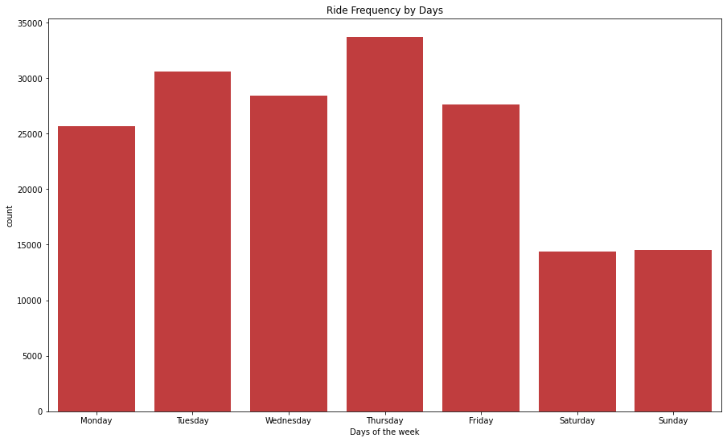

## DIstribution of Rides by Hours

On an hourly bases, most rides were taken around 8th and 9th hours (for morning) and 17th to 18th hours (for evening). This distribution may be linked to the morning and evening rush hours.

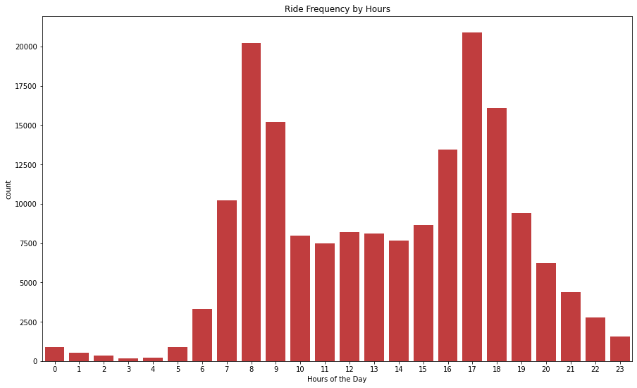

## Distribution of Riders by Age

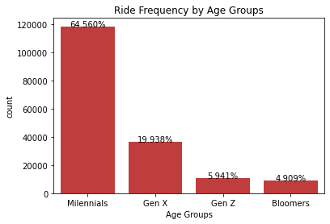

## Distribution of Riders by Gender

Majority of the riders are male

```
<function matplotlib.pyplot.show(close=None, block=None)>
```

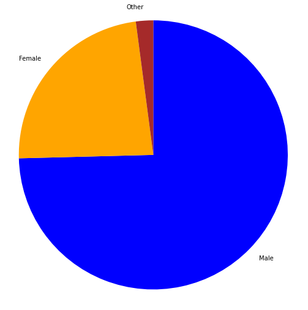

## Distribution of Riders by User type

Subscribers make up over 90% of users for the month in view.

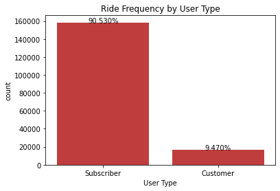

> Computing for the user demograph that averages out the longest ride.

## Average Ride Duration by Age group

[figure not shown]

## Average Trip Duration Across Week days and Genders

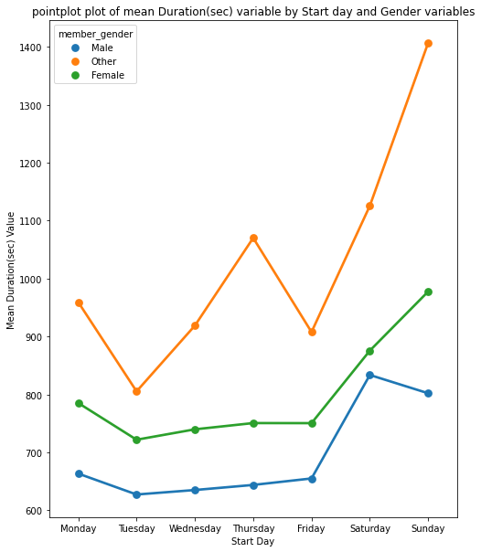